# QMB 6304 Analytical Methods for Business | Module 8 Assignment

Pablo Zumba | U54252888

8/5/2022

Write a simple R script to execute the following data preprocessing and statistical analysis.  
Where required show analytical output and interpretations.

## Preprocessing

**Preprocessing 1**

**1. Load the file “6304 Module 8 Assignment Data.xlsx” into R. This file contains information on 46,484 vehicles listed for sale on Craig’s List in the United States. This will be your master data set.**

```r
rm(list=ls())
library(rio)
library(car)
library(moments)
library(dplyr)
set.seed(54252888)
master_dataset=rio::import("6304 Module 8 Assignment Data.xlsx")
colnames(master_dataset)=tolower(make.names(colnames(master_dataset)))
str(master_dataset)
```

```
## 'data.frame':    46484 obs. of  10 variables:
##  $ region      : chr  "albuquerque" "albuquerque" "albuquerque" "albuquerque" ...
##  $ asking.price: num  15500 17995 18995 8998 22500 ...
##  $ year        : chr  "1965" "2015" "2014" "2012" ...
##  $ make        : chr  "ford" "ford" "ram" "volkswagen" ...
##  $ model       : chr  "mustang" "transit" "promaster 2500" "jetta tdi" ...
##  $ condition   : chr  "excellent" "good" "good" "excellent" ...
##  $ cylinders   : chr  "8" "6" "6" "4" ...
##  $ fuel        : chr  "gas" "gas" "gas" "diesel" ...
##  $ odometer    : num  4800 71181 80483 89000 15700 ...
##  $ paint.color : chr  "blue" "white" "white" "white" ...
```

## Filtering and creating a stratified sample

**Preprocessing 2**

**2. Create a single data frame for your analysis which will be your primary data set. The primary data set should have the following characteristics:**

- Only includes cars from the regions of Vermont, Appleton, green bay, Indianapolis, and Worcester.
- Only includes cars with 4, 6, or 8-cylinder engines.
- Includes all variables appearing in the master (N=46,484) data set.
- Be a random sample of n=50 cars from each of the five regions listed above. This is referred to as a stratified sample. (Remember to use the numerical portion of your U number as the random number seed.)

```r
primary_dataset=subset(master_dataset,region=="vermont"|region=="appleton"|region=="green bay"
                       |region=="indianapolis"|region=="worcester")
unique(primary_dataset$region)
```

```
## [1] "appleton"     "green bay"    "indianapolis" "vermont"      "worcester"
```

```r
primary_dataset=subset(primary_dataset,cylinders=="4"|cylinders=="6"|cylinders=="8")
unique(primary_dataset$cylinders)
```

```
## [1] "8" "4" "6"
```

```r
stratifiedSample = primary_dataset %>%
  group_by(region) %>%
  sample_n(size=50)
stratifiedSample$region=as.factor(stratifiedSample$region)
stratifiedSample$cylinders=as.factor(stratifiedSample$cylinders)
str(stratifiedSample)
```

```
## grouped_df [250 × 10] (S3: grouped_df/tbl_df/tbl/data.frame)
##  $ region      : Factor w/ 5 levels "appleton","green bay",..: 1 1 1 1 1 1 1 1 1 1 ...
##  $ asking.price: num [1:250] 19995 5475 10000 6000 3900 ...
##  $ year        : chr [1:250] "2014" "2013" "2012" "2013" ...
##  $ make        : chr [1:250] "ford" "chevrolet" "volkswagen" "hyundai" ...
##  $ model       : chr [1:250] "e350 superduty" "sonic" "jetta" "elantra" ...
##  $ condition   : chr [1:250] "excellent" "excellent" "excellent" "good" ...
##  $ cylinders   : Factor w/ 3 levels "4","6","8": 3 1 1 1 1 2 2 1 1 3 ...
##  $ fuel        : chr [1:250] "gas" "gas" "diesel" "gas" ...
##  $ odometer    : num [1:250] 109826 132000 99746 153000 184000 ...
##  $ paint.color : chr [1:250] "white" "blue" "black" "black" ...
##  - attr(*, "groups")= tibble [5 × 2] (S3: tbl_df/tbl/data.frame)
##   ..$ region: Factor w/ 5 levels "appleton","green bay",..: 1 2 3 4 5
##   ..$ .rows : list<int> [1:5]
##   .. ..$ : int [1:50] 1 2 3 4 5 6 7 8 9 10 ...
##   .. ..$ : int [1:50] 51 52 53 54 55 56 57 58 59 60 ...
##   .. ..$ : int [1:50] 101 102 103 104 105 106 107 108 109 110 ...
##   .. ..$ : int [1:50] 151 152 153 154 155 156 157 158 159 160 ...
##   .. ..$ : int [1:50] 201 202 203 204 205 206 207 208 209 210 ...
##   .. ..@ ptype: int(0)
##   ..- attr(*, ".drop")= logi TRUE
```

```r
attach(stratifiedSample)
```

## Analysis 1 | Determining equality of variance

**1. Within your n=250 stratified sample, determine if asking.price has an equal variance across the five regions. Briefly interpret your results**

```r
leveneTest(asking.price~region,data=stratifiedSample)
```

|  | Df | F value | Pr(>F) |
| --- | --- | --- | --- |
| group | 4 | 4.136889 | 0.002916841 |
|  | 245 | NA | NA |

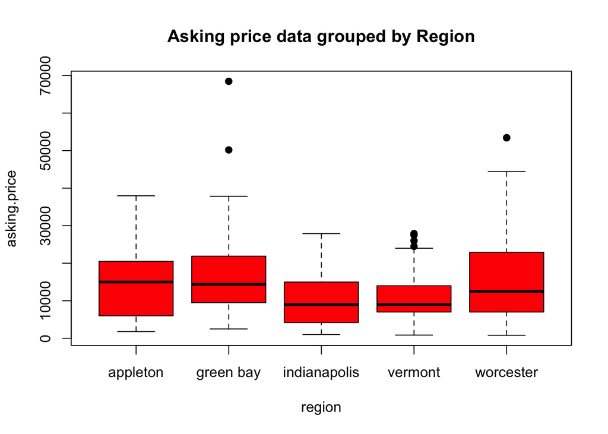

```r
boxplot(asking.price~region,pch=19,col="red",
        main="Asking price data grouped by Region")
```

```r
list_variance1=aggregate(asking.price~region,stratifiedSample,var)
list_variance1[order(-list_variance1$asking.price),]
```

|  | region | asking.price |
| --- | --- | --- |
| 5 | worcester | 162684253 |
| 2 | green bay | 149899736 |
| 1 | appleton | 100099380 |
| 4 | vermont | 43684628 |
| 3 | indianapolis | 43267309 |

Interpretation: “asking.price” does not satisfy the equality of variances. Using the “asking.price” variable, we find the Lavene test produces a p-value of 0.2917% (less than 5%), which means we can reject the Null hypothesis in favor of the alternate hypothesis, namely that there is at least one variance in a region that is different from the other ones. According to the descending order variance table above, Vermont and Indianapolis regions have significantly different variances from the rest regions (this can also be seen in the boxplot).

## Analysis 2 | One Way ANOVA: asking.price ~ region

**2. Conduct a one-way analysis of variance on your sample data with asking.price as the dependent variable and region as the independent variable. Plot the results of a Tukey HSD test to show whether/where differences in asking.price among the regions exist. Briefly explain the results shown in the plot, stating which pairs of regions do and do not appear to show significant mean differences in asking.price. Make sure region names can be clearly and completely read on the appropriate axis of your plot.**

```r
analysis2.out=aov(asking.price~region,data=stratifiedSample)
summary(analysis2.out)
```

```
##              Df    Sum Sq   Mean Sq F value Pr(>F)
## region        4 1.769e+09 442150190   4.425 0.0018 **
## Residuals   245 2.448e+10  99927061
## ---
## Signif. codes:  0 '***' 0.001 '**' 0.01 '*' 0.05 '.' 0.1 ' ' 1
```

```r
analysis2.out$coefficients
```

```
##        (Intercept)    regiongreen bay regionindianapolis      regionvermont
##           15444.12            1230.94           -5079.88           -4269.30
##    regionworcester
##             776.94
```

```r
list_means2=aggregate(asking.price~region,stratifiedSample,mean)
list_means2[order(-list_means2$asking.price),]
```

|  | region | asking.price |
| --- | --- | --- |
| 2 | green bay | 16675.06 |
| 5 | worcester | 16221.06 |
| 1 | appleton | 15444.12 |
| 4 | vermont | 11174.82 |
| 3 | indianapolis | 10364.24 |

```r
tukey1=TukeyHSD(analysis2.out)
tukey1
```

```
##   Tukey multiple comparisons of means
##     95% family-wise confidence level
##
## Fit: aov(formula = asking.price ~ region, data = stratifiedSample)
##
## $region
##                            diff         lwr          upr     p adj
## green bay-appleton      1230.94  -4263.4577  6725.337724 0.9725046
## indianapolis-appleton  -5079.88 -10574.2777   414.517724 0.0850873
## vermont-appleton       -4269.30  -9763.6977  1225.097724 0.2084941
## worcester-appleton       776.94  -4717.4577  6271.337724 0.9951487
## indianapolis-green bay -6310.82 -11805.2177  -816.422276 0.0153221
## vermont-green bay      -5500.24 -10994.6377    -5.842276 0.0496098
## worcester-green bay     -454.00  -5948.3977  5040.397724 0.9994073
## vermont-indianapolis     810.58  -4683.8177  6304.977724 0.9942882
## worcester-indianapolis  5856.82    362.4223 11351.217724 0.0302234
## worcester-vermont       5046.24   -448.1577 10540.637724 0.0886505
```

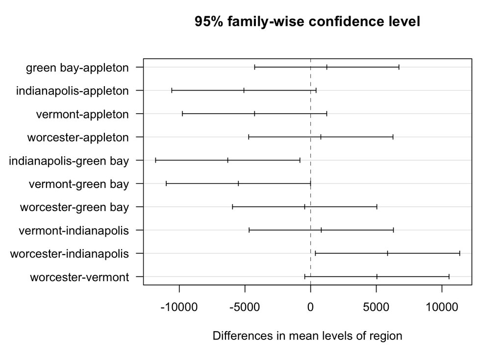

```r
par(mar=c(5.1,10,4.1,2.1))
plot(tukey1,las=1)
```

```r
par(mar=c(5.1,4.1,4.1,2.1))
```

## Analysis 3 | One Way ANOVA: odometer ~ region

**3. Repeat Steps 1 and 2 above using the odometer as the dependent variable and the region as the independent variable. Again, briefly explain your analysis results and make sure region names can be clearly and completely read on the appropriate axis of your plot.**

```r
leveneTest(odometer~region,data=stratifiedSample)
```

|  | Df | F value | Pr(>F) |
| --- | --- | --- | --- |
| group | 4 | 1.831265 | 0.123396 |
|  | 245 | NA | NA |

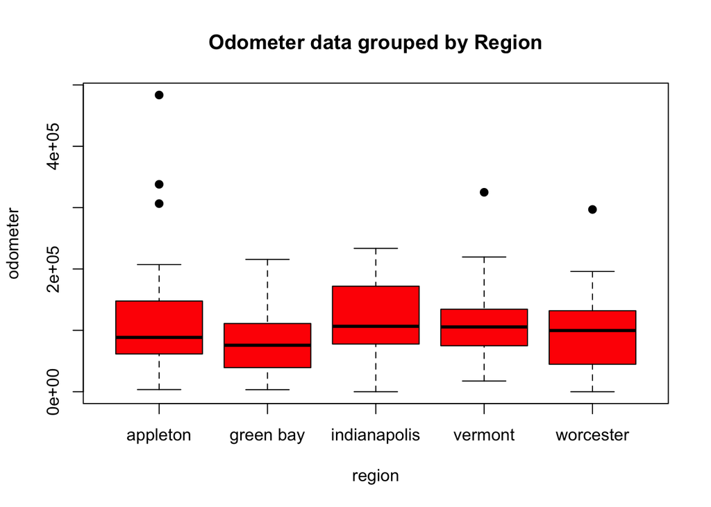

```r
boxplot(odometer~region,pch=19,col="red",
        main="Odometer data grouped by Region")
```

```r
list_variance2=aggregate(odometer~region,stratifiedSample,var)
list_variance2[order(-list_variance2$odometer),]
```

|  | region | odometer |
| --- | --- | --- |
| 1 | appleton | 7784319868 |
| 3 | indianapolis | 4015769406 |
| 5 | worcester | 3393090230 |
| 4 | vermont | 2965265560 |
| 2 | green bay | 2717930264 |

```r
analysis3.out=aov(odometer~region,data=stratifiedSample)
summary(analysis3.out)
```

```
##              Df    Sum Sq   Mean Sq F value Pr(>F)
## region        4 3.592e+10 8.979e+09   2.151 0.0752 .
## Residuals   245 1.023e+12 4.175e+09
## ---
## Signif. codes:  0 '***' 0.001 '**' 0.01 '*' 0.05 '.' 0.1 ' ' 1
```

```r
analysis3.out$coefficients
```

```
##        (Intercept)    regiongreen bay regionindianapolis      regionvermont
##          109756.80          -27268.38            5993.88            -180.74
##    regionworcester
##          -13570.12
```

```r
list_means3=aggregate(odometer~region,stratifiedSample,mean)
list_means3[order(-list_means3$odometer),]
```

|  | region | odometer |
| --- | --- | --- |
| 3 | indianapolis | 115750.68 |
| 1 | appleton | 109756.80 |
| 4 | vermont | 109576.06 |
| 5 | worcester | 96186.68 |
| 2 | green bay | 82488.42 |

```r
tukey3=TukeyHSD(analysis3.out)
tukey3
```

```
##   Tukey multiple comparisons of means
##     95% family-wise confidence level
##
## Fit: aov(formula = odometer ~ region, data = stratifiedSample)
##
## $region
##                             diff        lwr       upr     p adj
## green bay-appleton     -27268.38 -62784.137  8247.377 0.2190928
## indianapolis-appleton    5993.88 -29521.877 41509.637 0.9904473
## vermont-appleton         -180.74 -35696.497 35335.017 1.0000000
## worcester-appleton     -13570.12 -49085.877 21945.637 0.8316361
## indianapolis-green bay  33262.26  -2253.497 68778.017 0.0784440
## vermont-green bay       27087.64  -8428.117 62603.397 0.2250785
## worcester-green bay     13698.26 -21817.497 49214.017 0.8267632
## vermont-indianapolis    -6174.62 -41690.377 29341.137 0.9893078
## worcester-indianapolis -19564.00 -55079.757 15951.757 0.5544622
## worcester-vermont      -13389.38 -48905.137 22126.377 0.8383946
```

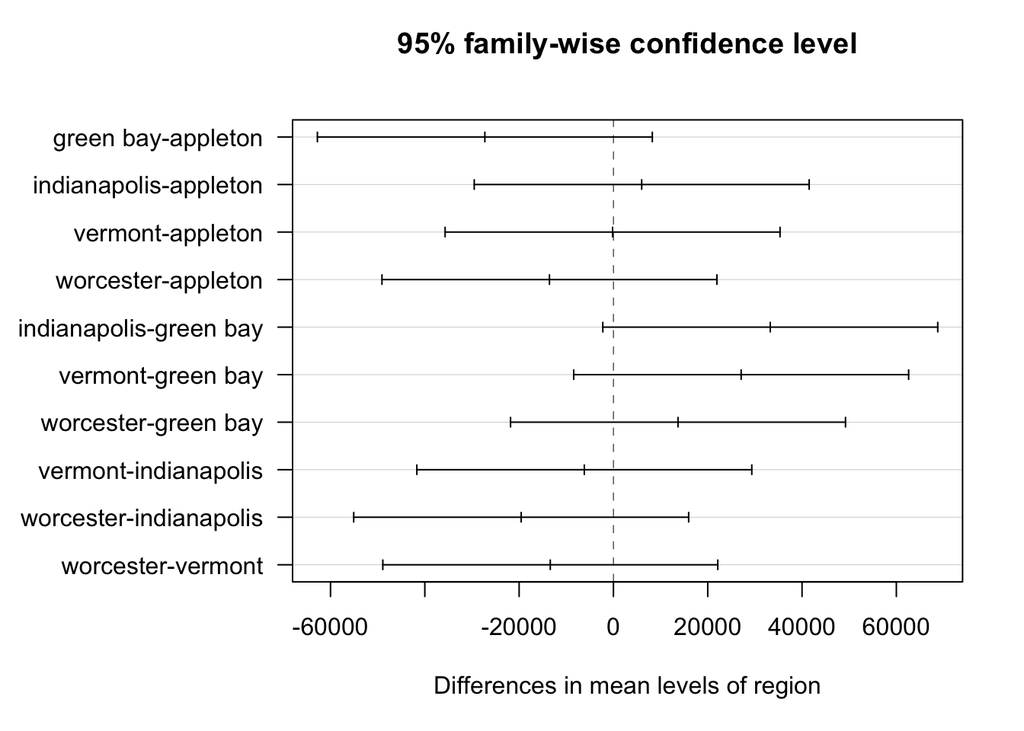

```r
par(mar=c(5.1,10,4.1,2.1))
plot(tukey3,las=1)
```

```r
par(mar=c(5.1,4.1,4.1,2.1))
```

Interpretation: Odometer readings in the five regions do not differ significantly (p-value 12.3% > 5% | fail to reject the Null Hypothesis) according to the Lavene test. According to the plot “Odometer data grouped by Region”, there are no significant differences in mean among the five regions. An Indianapolis-Green Bay combination has a very close difference in mean, but it needs to be analyzed using more observations to make a narrow confidence interval.

## Analysis 4 | One Way ANOVA: asking.price ~ cylinders

**4. Referring to Steps 1 and 2 again, conduct a one-way analysis of variance using asking.price as the dependent variable and cylinders as the independent. Show model output and explain your results as you did in Step 3.**

```r
leveneTest(asking.price~cylinders,data=stratifiedSample)
```

|  | Df | F value | Pr(>F) |
| --- | --- | --- | --- |
| group | 2 | 16.76247 | 1.491405e-07 |
|  | 247 | NA | NA |

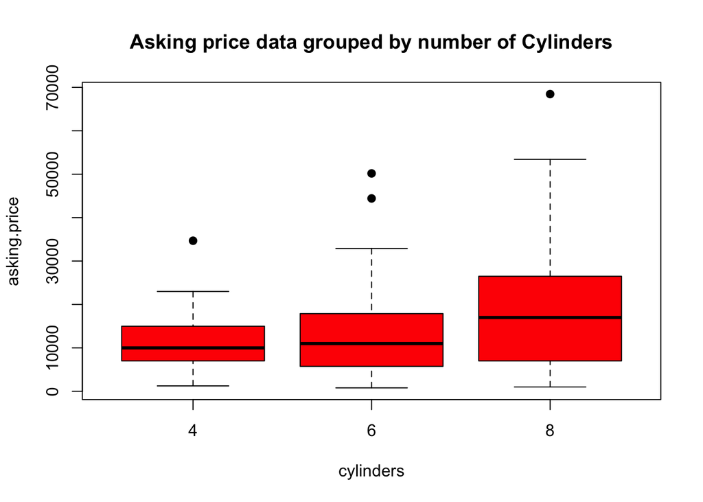

```r
boxplot(asking.price~cylinders,pch=19,col="red",
        main="Asking price data grouped by number of Cylinders")
```

```r
list_variance3=aggregate(asking.price~cylinders,stratifiedSample,var)
list_variance3[order(-list_variance3$asking.price),]
```

|  | cylinders | asking.price |
| --- | --- | --- |
| 3 | 8 | 180269319 |
| 2 | 6 | 93615299 |
| 1 | 4 | 32050507 |

```r
analysis4.out=aov(asking.price~cylinders,data=stratifiedSample)
summary(analysis4.out)
```

```
##              Df    Sum Sq   Mean Sq F value   Pr(>F)
## cylinders     2 2.306e+09 1.153e+09    11.9 1.17e-05 ***
## Residuals   247 2.394e+10 9.694e+07
## ---
## Signif. codes:  0 '***' 0.001 '**' 0.01 '*' 0.05 '.' 0.1 ' ' 1
```

```r
analysis4.out$coefficients
```

```
## (Intercept)  cylinders6  cylinders8
##   11170.584    1850.063    7376.895
```

```r
list_means4=aggregate(asking.price~cylinders,stratifiedSample,mean)
list_means4[order(-list_means4$asking.price),]
```

|  | cylinders | asking.price |
| --- | --- | --- |
| 3 | 8 | 18547.48 |
| 2 | 6 | 13020.65 |
| 1 | 4 | 11170.58 |

```r
tukey4=TukeyHSD(analysis4.out)
tukey4
```

```
##   Tukey multiple comparisons of means
##     95% family-wise confidence level
##
## Fit: aov(formula = asking.price ~ cylinders, data = stratifiedSample)
##
## $cylinders
##         diff       lwr       upr     p adj
## 6-4 1850.063 -1640.009  5340.136 0.4250352
## 8-4 7376.895  3710.956 11042.835 0.0000105
## 8-6 5526.832  1851.518  9202.145 0.0013559
```

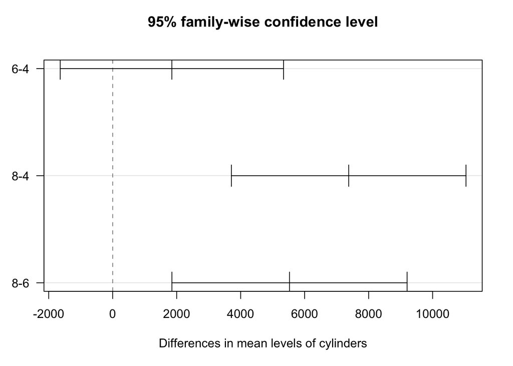

```r
par(mar=c(5.1,3,4.1,2.1))
plot(tukey4,las=1)
```

```r
par(mar=c(5.1,4.1,4.1,2.1))
```